# Materials+ML Workshop Day 5

## Day 5 Agenda:

- Questions about Day 4 Material
- Review of Day 4

Content for today:

- The Atomic Simulation Environment
  - Building atomic structures
  - Visualizing atomic structures
- Python Materials Genomics (`pymatgen` with `ase`)
  - Visualizing properties (band structure)
- Using the Materials Project Database
  - Querying material properties
  - Getting crystal structure data

## Background Survey

[figure not shown]

## https://forms.gle/ArUHPp2C6TdLF5dQ7

## The Workshop Online Book:

### https://cburdine.github.io/materials-ml-workshop/

## Tentative Week 1 Schedule:

| Session | Date | Content |
| --- | --- | --- |
| Day 1 | 06/09/2025 (2:00-4:00 PM) | Introduction, Python Data Types |
| Day 2 | 06/10/2025 (2:00-4:00 PM) | Python Functions and Classes |
| Day 3 | 06/11/2025 (2:00-4:00 PM) | Scientific Computing with Numpy and Scipy |
| Day 4 | 06/12/2025 (2:00-4:00 PM) | Data Manipulation and Visualization |
| **Day 5** | **06/13/2025 (2:00-4:00 PM)** | **Materials Science Packages, Introduction to ML** |

# Questions

Material covered yesterday:

- Pandas
- Matplotlib

# Review: Day 4

## Pandas

- Pandas is an open-source Python package for data manipulation and analysis.
- It can be used for reading writing data to several different formats including:
  - CSV (comma-separated values)
  - Excel spreadsheets
  - SQL databases
- We can import pandas as follows:

```python
import pandas as pd
```

## DataFrames

- We can create Dataframes from Python dictionaries as follows:

```python
# Data on the first four elements of the periodic table:
elements_data = {
    'Element' : ['H', 'He', 'Li', 'Be'],
    'Atomic Number' : [ 1, 2, 3, 4 ],
    'Mass' : [ 1.008, 4.002, 6.940, 9.012],
    'Electronegativity' : [ 2.20, 0.0, 0.98, 1.57 ]
}

# construct dataframe from data dictionary:
df = pd.DataFrame(elements_data)
```

```python
import numpy as np

# get the 'Mass' column and convert it to a numpy array:
mass_series = df['Mass']
mass_array = np.array(mass_series)

print(mass_array)
```

```
[1.008 4.002 6.94  9.012]
```

```python
# function for estimating mass:
def amu_mass(n):
    return 2*n

# add an "Estimated Mass" column to the dataframe:
df['Estimated Mass'] = \
    df['Atomic Number'].apply(amu_mass)
display(df)
```

|  | Element | Atomic Number | Mass | Electronegativity | Estimated Mass |
| --- | --- | --- | --- | --- | --- |
| 0 | H | 1 | 1.008 | 2.20 | 2 |
| 1 | He | 2 | 4.002 | 0.00 | 4 |
| 2 | Li | 3 | 6.940 | 0.98 | 6 |
| 3 | Be | 4 | 9.012 | 1.57 | 8 |

# Matplotlib

- Matplotlib is a MATLAB-like plotting utility for creating publication-quality plots
- In matplotlib, we typically import the `pyplot` subpackage with the alias `plt`:

```python
import matplotlib.pyplot as plt
```

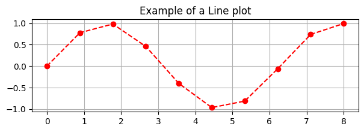

```python
# generate some data:
data_x = np.linspace(0,8,10)
data_y = np.sin(data_x)

# create a new figure and plot data:
plt.figure(figsize=(7,2))
plt.grid()
plt.plot(data_x, data_y, 'ro--')

# add a title and show plot in notebook:
plt.title('Example of a Line plot')
plt.show()
```

## New Content:

- Materials Science Python Packages:
  - ASE (Atomic Simulation Environment)
  - Pymatgen (Python Materials Genomics)
  - Materials Project API

## Installing packages:

- Install ASE:

```
pip install ase
```

```
pip install pymatgen
```

- Install Materials Project API

```
pip install mp-api
```

```python
pip install ase pymatgen mp-api
```

## The Atomic Simulation Environment

- ASE is a Python package for building, manipulating, and performing calculations on atomic structures
- ASE provides interfaces to several different simulation platforms, such as:
  - VASP
  - Quantum ESPRESSO
  - Q-Chem
  - Gaussian

## ASE Basics:

- The fundamental data type in ASE is the `Atoms` object:
  - `Atoms` represents a collection of Atoms in a molecular or crystalline structure.
  - Material properties (such as the results of calculations) can be attached to Atoms instances
- ASE has functionality for loading, exporting and viewing `Atoms` objects in different formats.

```python
from ase.build import molecule
from ase.visualize import view

# build a common molecule:
acetic_acid = molecule('CH3COOH')
view(acetic_acid, viewer='x3d')
```

[output not shown]

## Tutorial: ASE - The Atomic Simulation Environment

- Building simple molecules
- Building inorganic structures
  - MXenes
  - Carbon Nanotubes

## Exercise: ASE - The Atomic Simulation Environment

- Nitrogen-Vacancy Centers in Diamond

## The Materials Project

- Register for an account at https://next-gen.materialsproject.org/
- Once you have registered, find your API key under *My Dashboard*:

[figure not shown]

- Once you have copied your API key, paste it into your notebook as a string:

```python
# create a variable in your notebook with your API key
MP_API_KEY = '< Paste your API key here. >'
```

*Always avoid sharing your API key with others.*

## Tutorial: Working with the Materials Project

- YBCO is a high-temperature superconductor
- We will:
  - Visualize the crystal structure
  - Plot the Band Structure

## Exercise: Working with the Materials Project

- Visualize the DOS of YBa$_2$Cu$_3$O$_7$

# Questions

- Any questions about Week 1 or Week 2 Content?

## Additional Review: Statistics

- Survey Results: Familiarity with statistics (1-10 Scale)

[figure not shown]

## Additional Review: Linear Algebra

- Survey Results: Familiarity with Linear Algebra (1-10 Scale)

[figure not shown]

## Recommended Reading:

- Introduction to Machine Learning
  - Statistics Review (as needed)
  - Mathematics Review (as needed)
- Supervised Learning

If possible, try to do the exercises. Bring your questions to our next meeting (next Monday).